# Week4 - Final Project

Rob Hodde

November 29, 2015

### Summary:

This project is where you show off your ability to  
(1) use R packages,  
(2) change the shape of data in a data frame, and  
(3) provide basic summary statistics and graphics as part of your exploratory data analysis.

Design and populate tables in SQL, then export the data into R and create some basic explanatory data analysis.

. You should perform some basic transformations on the data frame, such as including only a subset of columns, created one or more new derived columns (such as flight date), and/or filtering out rows.

. You should then create basic summary statistics. You should create at least one interesting question for analysis, and answer the question using two or more graphics in R.

**Sources:**

Eve Data Relay: http://eve-marketdata.com/developers/mysql.txt

The database for this project is here:  
https://raw.githubusercontent.com/LovinSpoonful/Week4/e9c94119c4f22e23a08bbddab66c378f2a6e1e11/SQL%20-%20Final%20Project2.sql

MySQL Tricks: http://stackoverflow.com/questions/1895110/row-number-in-mysql – emulates ROW_NUMBER but not capable of partitioning.

R Tricks: http://harding.edu/fmccown/r/#barcharts

### Question:

An interesting question to aspiring Eve Online players the world over is, “How do I **get rich quick** on Eve, so I can buy lots of cool ships, run daring missions, and get really famous?”

The short answer to that question is, “You don’t.” However, there is some interesting data available from the Eve Data Relay that might be leveraged to help expedite the process.

### Solution:

Establish a connection to the mySQL database.

```r
# use the R ODBC package to establish a connection to mySQL database and select records into data frames
require(RODBC)
cnString <- "MySQL_ANSI;SERVER=localhost;DATABASE=eve2;UID=root;PASSWORD=CUNYRBridge4!;OPTION=3;"
db <- odbcConnect(cnString)
```

Since most Eve noobs live in The Forge region, let’s first look at things we can buy at The Forge and sell in another region.

```r
df <- sqlQuery(db,"SELECT item_name, avg(unit_margin) unit_margin FROM vw_top_trades WHERE sell_region_name = 'The Forge' GROUP BY item_name", stringsAsFactors = FALSE)

print(df)
```

```
##           item_name unit_margin
## 1 Nitrogen Isotopes        3016
```

As might be expected, only one item - Nitrogen Isotopes - is readily available at The Forge which can be sold for a large profit elsewhere. Let’s find out where we can sell this commodity at a good profit.

```r
df <- sqlQuery(db,"SELECT buy_region_name, buy_avg_price, buy_kunits_avail, unit_margin FROM vw_top_trades WHERE sell_region_name = 'The Forge'", stringsAsFactors = FALSE)

print(df)
```

```
##   buy_region_name buy_avg_price buy_kunits_avail unit_margin
## 1        Immensea          3950              212        3016
```

So this might be very discouraging to a new player.

Next question: “If not at The Forge, in which regions can I buy more trade-worthy items?”

Let’s look at all the regions with at least five excellent trade opportunities:

```r
df <- sqlQuery(db,"SELECT sell_region_name, COUNT(1) sell_items FROM vw_top_trades  GROUP BY sell_region_name HAVING COUNT(1) >= 5 ORDER BY COUNT(1) DESC", stringsAsFactors = FALSE)

print(df)
```

```
##   sell_region_name sell_items
## 1    Outer Passage         13
## 2            Omist          9
## 3      Cobalt Edge          8
## 4      Feythabolis          7
## 5           Branch          6
## 6     Period Basis          5
```

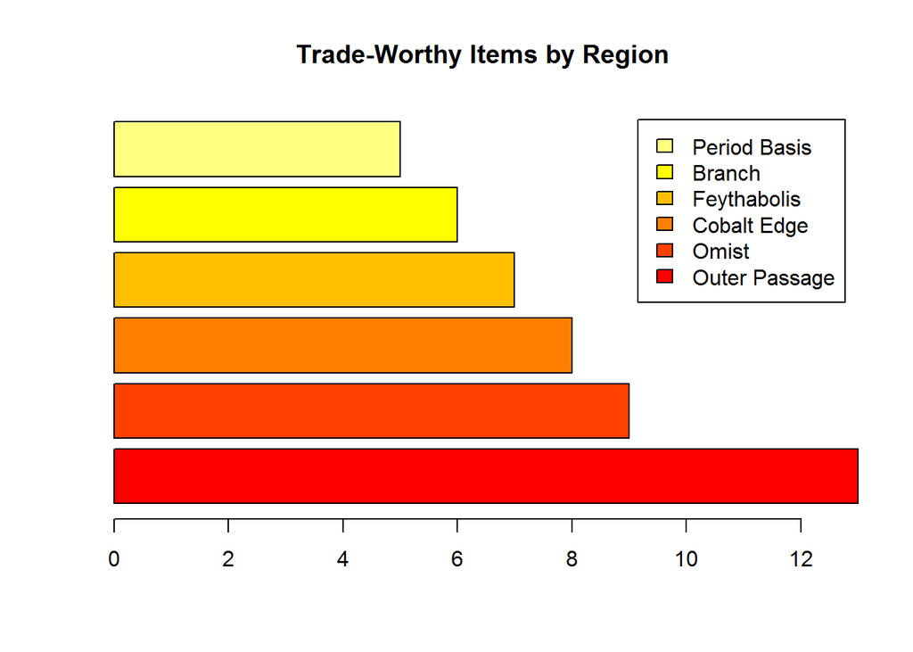

```r
barplot(df$sell_items,main="Trade-Worthy Items by Region",horiz=TRUE, col=heat.colors(nrow(df)), legend = df$sell_region_name)
```

Now we are getting somewhere. Let’s look at the Cobalt Edge region in more detail.

```r
df <- sqlQuery(db,"SELECT * FROM vw_top_trades WHERE sell_region_name = 'Cobalt Edge'", stringsAsFactors = FALSE)

print(df)
```

```
##              item_name buy_region_name buy_kunits_avail buy_avg_price
## 1    Nitrogen Isotopes        Immensea              212          3950
## 2 Strontium Clathrates       The Forge            35939           487
## 3 Strontium Clathrates     Sinq Laison            22437           469
## 4 Strontium Clathrates        Heimatar             3623           457
## 5 Strontium Clathrates          Domain             8598           411
## 6 Strontium Clathrates           Stain              270           357
## 7 Strontium Clathrates    Verge Vendor              186           332
## 8 Strontium Clathrates    Wicked Creek              259           331
##   sell_region_name sell_kunits_avail sell_avg_price unit_margin
## 1      Cobalt Edge               113           1100        2850
## 2      Cobalt Edge              2564            207         280
## 3      Cobalt Edge              2564            207         262
## 4      Cobalt Edge              2564            207         250
## 5      Cobalt Edge              2564            207         204
## 6      Cobalt Edge              2564            207         150
## 7      Cobalt Edge              2564            207         125
## 8      Cobalt Edge              2564            207         124
```

Looks like Cobalt Edge has lots of Strontium Clathrates for sale, with buyers in many regions at a good profit.

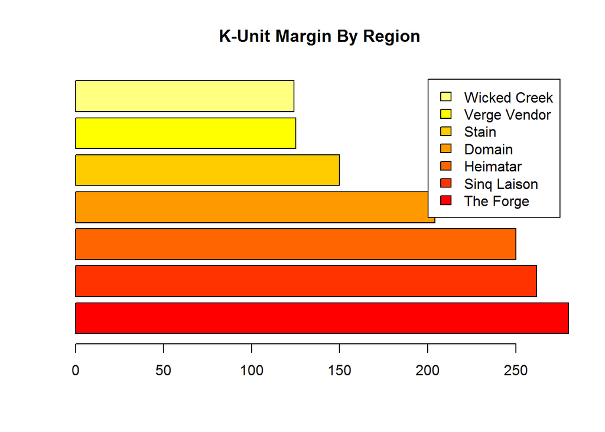

```r
dfb <- subset(df,sell_kunits_avail > 2000, select = c(buy_region_name, unit_margin))

barplot(dfb$unit_margin,main="K-Unit Margin By Region",horiz=TRUE, col=heat.colors(nrow(dfb)), legend = dfb$buy_region_name)
```

**Answer:**

It looks like the best way to get started making money in Eve is to go to Cobalt Edge, buy a bunch of Strontium Clathrates, ferry them over to The Forge, and sell them for a tidy profit of 280 ISK per k-unit.

One doesn’t simply login to Eve and do this, which opens the door for many follow-up research questions about the various steps one might take to achieve the objective.